# COMP60711 - Part 2 Coursework 1

[output not shown]

Please complete the questions in the spaces provided (under the "Answer" block for each question), then download the notebook in HTML format and submit to Blackboard.

Please also add your student ID and name below.

| Student ID (7-8 digit number) | Full Name |
| --- | --- |
| 10844274 | Hao Li |

## Reminders

- **Please make clear any assumptions and provide evidence to justify your answers**
- Jupyter notebooks use markdown. A brief summary of how to use markdown can be seen [here](https://github.com/adam-p/markdown-here/wiki/Markdown-Cheatsheet). Otherwise, please refer to the brief guide on Blackboard.
- You **must** cite any sources used, from web pages to academic papers and textbooks.
- Please ensure your code has no errors, and that the output is shown in your submitted version.
- We have added some general notebooks on Blackboard to cover the basics of plotting in Python, Jupyter notebooks, and anaconda.
- Some questions require a mixture of code and text to answer the question. Marks are awarded based on the output of your code (i.e. graphs) and the explanation provided, not on the code itself.

# Question 1: Clustering (16 marks)

The following sub-questions are about [clustering](https://www-users.cs.umn.edu/~kumar001/dmbook/ch8.pdf). In general, the topics covered are as follows:

- Question 1.1 focuses on clustering algorithmic behaviour, and their sensitivity to data.
- Question 1.2 focuses on method for estimating the number of clusters.
- Question 1.3 uses a large real-world dataset to look at how clustering can be used for knowledge discovery.

The following reading is likely to be of use for the following questions:

1. Book chapter on clustering: https://www-users.cs.umn.edu/~kumar001/dmbook/ch8.pdf
   - Note that certain sections may be useful, you are not expected to read it all!
2. Here is an example of running KMeans using scikit-learn: https://scikit-learn.org/stable/auto_examples/cluster/plot_kmeans_assumptions.html

For this question, we will use multiple datasets, which can all be found on Blackboard. To load these datasets in, we can use the following code. Note that you may need to adjust the path to the dataset, depending on where they are located on your system.

```python
import pandas as pd

def load_dataset(file_name, **kwargs):
    try:
        data = pd.read_csv(file_name, **kwargs)
    except FileNotFoundError:
        raise FileNotFoundError(f"Cannot find {file_name}, please either place the file in the same directory as this notebook, or provide the full path")
    labels = data.values[:, -1]
    data = data.values[:, :-1]
    return data, labels

# This loads the dataset used in Q1.1a
simple_data, simple_labels = load_dataset("simple.csv")
```

[output not shown]

## Q1.1 (6 marks)

### Q1.1a (2 marks)

Using `simple.csv`, run the K-Means and single-linkage algorithms (available in [`scikit-learn`](https://scikit-learn.org/stable/modules/clustering.html)) on the dataset, using the true number of clusters ($K=5$). Produce a graph (e.g. bar chart) showing the performance (measured using the [adjusted rand index](https://scikit-learn.org/stable/modules/generated/sklearn.metrics.adjusted_rand_score.html)) across 10 independent runs. Discuss the results obtained, using your knowledge of how the algorithms work to explain why the behaviour observed occurred.

**Hints:**

- This question is more difficult without the use of error bars!
- For single-linkage, use `AgglomerativeClustering(n_clusters=5, linkage="single")`
- For KMeans, use `KMeans(n_clusters=5, init="random", n_init=1)` as arguments.

### Q1.1a Answer

```python
# Please enter any relevant code for Q1.1a below.
# You can use multiple cells if it helps break up the code execution
from numpy import arange
import seaborn as sns
from sklearn.metrics.cluster import adjusted_rand_score
from sklearn.cluster import KMeans
from sklearn.cluster import AgglomerativeClustering
kmean_pred = KMeans(n_clusters=5, init="random", n_init=1).fit_predict(simple_data)
pred_k = adjusted_rand_score(simple_labels,kmean_pred)
print(pred_k)
sl_pred = AgglomerativeClustering(n_clusters=5, linkage="single").fit_predict(simple_data)
pred_single=adjusted_rand_score(simple_labels,sl_pred)
print(pred_single)
```

```
0.8465510931369654
0.7070569794383634
```

```python
# K mean cluster 1
k_performance= []
kmean_pred1 = KMeans(n_clusters=5, init="random", n_init=1).fit_predict(simple_data)
pred_k1 = adjusted_rand_score(simple_labels,kmean_pred1)
print(pred_k1)
k_performance.append(pred_k1)
```

```
1.0
```

```python
# K mean cluster 2
kmean_pred2 = KMeans(n_clusters=5, init="random", n_init=1).fit_predict(simple_data)
pred_k2 = adjusted_rand_score(simple_labels,kmean_pred2)
print(pred_k2)
k_performance.append(pred_k2)
```

```
0.6095448663594977
```

```python
# K mean cluster 3
kmean_pred3 = KMeans(n_clusters=5, init="random", n_init=1).fit_predict(simple_data)
pred_k3 = adjusted_rand_score(simple_labels,kmean_pred3)
print(pred_k3)
k_performance.append(pred_k3)
```

```
0.6063046104668882
```

```python
kmean_pred4 = KMeans(n_clusters=5, init="random", n_init=1).fit_predict(simple_data)
pred_k4 = adjusted_rand_score(simple_labels,kmean_pred4)
print(pred_k4)
k_performance.append(pred_k4)
```

```
0.6756053721572931
```

```python
kmean_pred5 = KMeans(n_clusters=5, init="random", n_init=1).fit_predict(simple_data)
pred_k5 = adjusted_rand_score(simple_labels,kmean_pred5)
print(pred_k5)
k_performance.append(pred_k5)
```

```
1.0
```

```python
kmean_pred6 = KMeans(n_clusters=5, init="random", n_init=1).fit_predict(simple_data)
pred_k6 = adjusted_rand_score(simple_labels,kmean_pred6)
print(pred_k6)
k_performance.append(pred_k6)
```

```
0.9181958623574702
```

```python
kmean_pred7 = KMeans(n_clusters=5, init="random", n_init=1).fit_predict(simple_data)
pred_k7 = adjusted_rand_score(simple_labels,kmean_pred7)
print(pred_k7)
k_performance.append(pred_k7)
```

```
1.0
```

```python
kmean_pred8 = KMeans(n_clusters=5, init="random", n_init=1).fit_predict(simple_data)
pred_k8 = adjusted_rand_score(simple_labels,kmean_pred8)
print(pred_k8)
k_performance.append(pred_k8)
```

```
0.6778937091169306
```

```python
kmean_pred9 = KMeans(n_clusters=5, init="random", n_init=1).fit_predict(simple_data)
pred_k9 = adjusted_rand_score(simple_labels,kmean_pred9)
print(pred_k9)
k_performance.append(pred_k9)
```

```
0.8461278613243107
```

```python
kmean_pred10 = KMeans(n_clusters=5, init="random", n_init=1).fit_predict(simple_data)
pred_k10 = adjusted_rand_score(simple_labels,kmean_pred10)
print(pred_k10)
k_performance.append(pred_k10)
print(k_performance)
```

```
1.0
[1.0, 0.6095448663594977, 0.6063046104668882, 0.6756053721572931, 1.0, 0.9181958623574702, 1.0, 0.6778937091169306, 0.8461278613243107, 1.0]
```

```python
s_performance =[]
running_time = []
k_list =[]
s_list =[]
for i in range(10):
    sl_pred = AgglomerativeClustering(n_clusters=5, linkage="single").fit_predict(simple_data)
    pred_single=adjusted_rand_score(simple_labels,sl_pred)
    s_performance.append(pred_single)
    k_list.append('k-means')
    s_list.append('single-linkage')
average_k = sum(k_performance)/len(k_performance)
average_s = sum(s_performance)/len(s_performance)
print(average_k)
print(average_s)
```

```
0.8333672281782392
0.7070569794383633
```

```
         Algorithm  Performance
0          k-means     1.000000
1          k-means     0.609545
2          k-means     0.606305
3          k-means     0.675605
4          k-means     1.000000
5          k-means     0.918196
6          k-means     1.000000
7          k-means     0.677894
8          k-means     0.846128
9          k-means     1.000000
10  single-linkage     0.707057
11  single-linkage     0.707057
12  single-linkage     0.707057
13  single-linkage     0.707057
14  single-linkage     0.707057
15  single-linkage     0.707057
16  single-linkage     0.707057
17  single-linkage     0.707057
18  single-linkage     0.707057
19  single-linkage     0.707057
```

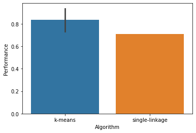

```python
import matplotlib.pyplot as plt
import seaborn as sns
df = pd.DataFrame({
    'Algorithm':k_list+s_list,
    'Performance': k_performance+s_performance
})
print(df)
ax = sns.barplot(x='Algorithm',y="Performance",data=df)
```

#### Discussion of Q1.1a:

Overall, working with this dataset, the k-means algorithm shows better performance than single-linkage. Normally, choosing a suitable k value for the k-means algorithm is a challenge for users. It will affect the performance of k-means[1]. For this dataset, it provided labels in advance. This point makes the k-means algorithm perform well, and the average score reaches 0.8 in this case. However, there is another point worth noticing.From the output bar chart, it is clear that an error bar is shown in the k-means performance score. In the data visualization domain, an error bar is a helpful tool. It purposes to figure out any estimated error or uncertainty problem in the graph [2].

Such an estimated error in the k-means algorithm is a reasonable result. The working step of the k-means algorithm is[1]:

1. Choose initial centroids randomly.
2. Assigning each point to the closest centroid, then that is the initial clusters.
3. For each cluster, get the average of all points to get new centroids. Then assign all points to the closest centroid. Then we can get the new cluster.
4. Repeat step 3 to get a new centroid and new cluster until all points stop changing clusters.

Therefore, the unstable problem is caused by choosing the initial centroid. Since for every independent run, the algorithm chooses different initial centroid randomly. Tan states that poor initial centroids are possible to get poor results. One of the solutions to figure out this random problem is to run the k-means algorithm multiple times. It is able to reduce the effect of random initial centroid problems. Then the result could be more reliable .

### Q1.1b (2 marks)

Using the dataset named `q1-1b.csv`, perform the same experiment as in Q1.1a. Discuss the ARI results obtained, particularly how and why the results are different from Q1.1a.

**Hint:**

- Visualizing the data itself may help to support your discussion.

### Q1.1b Answer

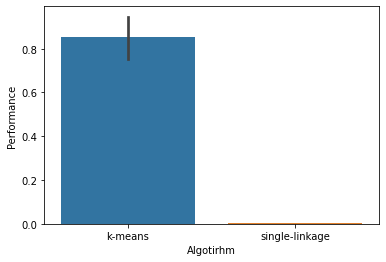

```python
simple_data1b, simple_labels1b = load_dataset("q1-1b.csv")
kb_performance = []
for x in range(10):
    kmean_pred1b = KMeans(n_clusters=5, init="random", n_init=1).fit_predict(simple_data1b)
    pred_kb = adjusted_rand_score(simple_labels1b,kmean_pred1b)
    kb_performance.append(pred_kb)
s_performance1b = []
for y in range(10):
    sl_pred1b = AgglomerativeClustering(n_clusters=5, linkage="single").fit_predict(simple_data1b)
    pred_single1b=adjusted_rand_score(simple_labels1b,sl_pred1b)
    s_performance1b.append(pred_single1b)
df = pd.DataFrame({
    'Algotirhm':k_list+s_list,
    'Performance': kb_performance+s_performance1b
})
ax = sns.barplot(x="Algotirhm", y="Performance",ci=95 ,data=df)
```

#### Discussion of Q1.1b:

From the result of this dataset, the k-means algorithm shows significantly better performance than single-linkage. One of the points worth noticing for this output is the performance score of the single-linkage algorithm. The single-linkage algorithm is one kind of hierarchical clustering. The step and principles of the single-linkage algorithm are straightforward. Firstly, all elements are in a single cluster. Each cluster only contains one element. In each iteration, merge two closest clusters until all elements are in one cluster. The distance between two clusters depends on the elements from these two clusters [1]. The limitation of a single-linkage algorithm is noise and outliers. To clarify this problem. Assuming that is a case:

Cluster 1: element1(1,1), element2(1,2)

Cluster 2: element3(1,-1), element4(2,-2)

Cluster 3: element5(-2,1), element6(-2,2)

### Q1.1c (2 marks)

Using the dataset named `q1-1c.csv`, perform the same experiment as in Q1.1b. Discuss the results obtained, particularly how and why the results are different from Q1.1b.

**Hints:**

- Visualizing the data itself may help to support your discussion.

### Q1.1c Answer

```
[1.0, 1.0, 1.0, 1.0, 1.0, 1.0, 1.0, 1.0, 1.0, 1.0]
```

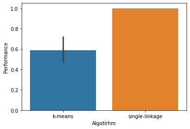

```python
# Please enter any relevant code for Q1.1c below.
# You can use multiple cells if it helps
simple_data1c, simple_labels1c = load_dataset("q1-1c.csv")
kc_performance = []
for a in range(10):
    kmean_pred1c = KMeans(n_clusters=5, init="random", n_init=1).fit_predict(simple_data1c)
    pred_kc = adjusted_rand_score(simple_labels1c,kmean_pred1c)
    kc_performance.append(pred_kc)
s_performance1c = []
for b in range(10):
    sl_pred1c = AgglomerativeClustering(n_clusters=5, linkage="single").fit_predict(simple_data1c)
    pred_single1c=adjusted_rand_score(simple_labels1c,sl_pred1c)
    s_performance1c.append(pred_single1c)
df = pd.DataFrame({
    'Algotirhm':k_list+s_list,
    'Performance': kc_performance+s_performance1c
})
print(s_performance1c)
ax = sns.barplot(x="Algotirhm", y="Performance",ci=95 ,data=df)
```

#### Discussion of Q1.1c:

From the Q1.1c output, the single-linkage score performed well for this dataset. Compare with output in Q1.1b, the size of these two datasets are the same. However, the performance of the single-linkage algorithm is great and stable. Therefore, it could prove single-linkage algorithm is a sensible approach to cluster for the dataset in some cases. As we discussed in the early section, the limitation of single-linkage algorithm is noise and outliers data. Another point worth noticing from this output is the performance of the k-means algorithm. The score has reduced from 0.8 to 0.6. Moreover, the error bar is longer than the past graph.

In conclusion, both of these two algorithms could be seen as possible approaches to solve the clustering problem. It is not able to claim which algorithm is significantly better than another. The choice of clustering method will depend on the dataset, and it requires some experiment to find suitable algorithm for the working dataset.

## Q1.2 (5 marks)

### Q1.2a (3 marks)

Discuss **two** methods that can be used to estimate the *true* number of clusters. A discussion of the suitability and potential issues with each method is expected. No marks are given beyond the first two methods.

### Q1.2a Answer

```python
# Please enter any relevant code for Q1.2a below
# You can use multiple cells if it helps
```

#### The discussion of q1.2a

For estimate the true number of clusters, there are two sensible approach called "Silhouette Coefficient" and "Calinski-Harabasz Index".

##### Silhouette Coefficient

The silhouette coefficient is a metric used to measure the performance of a clustering technique [3]. The result of the silhouette coefficient will between -1 to 1. The negative silhouette value indicates clusters assigned in the wrong way. 0 indicates the difference between each cluster is not clear enough. 1 indicates clusters with fair distance, and it is able to distinguish accurately.

Therefore, it could set a range of the true number of clusters. Then run the k-means algorithm with these values as k value. Storing these results to the data set. Finally, use silhouette coefficient to evaluate the set of k-mean algorithm results. The higher score indicates the corresponding number of clusters is suitable for the dataset.

The potential issue of the silhouette is the clusters algorithm may affect the result of the silhouette score. Normally, convex clusters will get a higher Silhouette score than other concepts of clusters [3]. To reduce the effect of issues, users could run different algorithms and compare the Silhouette score to get a better result.

##### Calinski-Harabasz Index

Another method called "Calinski-Harabasz Index", it is also called "Variance Ratio Criterion". The compute speed of this method is fast. This method will take all clusters, Then compute the ratio of between-clusters dispersion and inter-cluster dispersion for all clusters[3]. Higher scores indicate better performance. Therefore, it could set a range of values again. Then run the k-means algorithm with this set of ranges as k value. Using this method to evaluate the k-mean algorithm results. The highest Calinski-Harabasz means the corresponding number of clusters is suitable for the dataset, and it could be the true number of clusters for the data set.

The issue of Calinski-Harabasz is similar to Silhouette Coefficient. The convex clusters may get better Calinski-Harabasz score than other concepts of clusters.

### Q1.2b (2 marks)

Using the `simple.csv` dataset, apply one of the two methods discussed in Q1.2a to estimate the true number of clusters. Was the estimate correct? Discuss your result.

### Q1.2b Answer

```
       Score  set n as cluster
0   0.570427                 2
1   0.622073                 3
2   0.690689                 4
3   0.732576                 5
4   0.601230                 6
5   0.535626                 7
6   0.497991                 8
7   0.458221                 9
8   0.399124                10
9   0.385512                11
10  0.369459                12
11  0.380404                13
12  0.379767                14
13  0.363352                15
```

[output cut: 23 more lines]

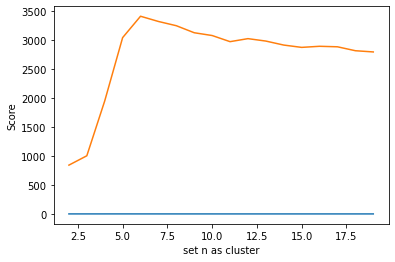

```python
from sklearn import metrics
from sklearn.metrics import pairwise_distances
from sklearn import datasets
import matplotlib.pyplot as plt
import numpy as np
list12b=[]
list12b_helper = []
list12b2 =[]
for q12b in range(2,20):
    kmeans_model = KMeans(n_clusters=q12b, random_state=1).fit(simple_data)
    labels = kmeans_model.labels_
    list12b2.append(metrics.calinski_harabasz_score(simple_data, labels))
    list12b.append(metrics.silhouette_score(simple_data, labels, metric='euclidean'))
    list12b_helper.append(q12b)
df = pd.DataFrame({
    'Score':list12b,
    'set n as cluster': list12b_helper
})
print(df)
sns.lineplot(data=df, x='set n as cluster', y='Score')
df2 = pd.DataFrame({
    'Score':list12b2,
    'set n as cluster': list12b_helper
})
print(df2)
sns.lineplot(data=df2, x='set n as cluster', y='Score')
```

From the output graph, the n = 5 shows the best silhouette score which equals 0.73. For Calinski Harabasz index, n = 6 shows the highest Calinski-Harabasz score. Since the best k-value result of these two methods is close. It means these two methods are able to find the true number of clusters for the data set.

## Q1.3 (5 marks)

For this question, we will use the `online_retail_full.csv` dataset, which is a real-world dataset of transactions for an online retail store. Full information about the dataset can be found [here](https://archive.ics.uci.edu/ml/datasets/Online+Retail+II). Here, we do not have true labels, and need to explore the data instead. This is a common scenario in practice, and will require you explore the data and use clustering (likely requiring multiple iterations and tweaks) to try to find patterns.

We're going to investigate whether there are groups of customers, how they are similar, and what they may represent. For simplicity, we will start by using KMeans as our model, and we'll remove some of the columns from our input data. Use a range of $K$ values and whichever techniques in Q1.2 are useful to propose interesting $K$ value(s). Comment on the clusters that are produced in terms of the context of the data.

Hints:

- As this dataset has no truth, there is a lot of scope in this question - remember to have some justification for why you have taken the steps you have.
- The quality of your final clusters is not important for marks, as long as you have taken reasonable steps.
- The overall aim is to try to find patterns in the data. KMeans is suggested as a starting point, but it is not always the best algorithm to use as we have seen in previous questions.
- You can create features from the existing ones. For example, the quantity and price can be multiplied to get a total amount (thus simplifying the data). Other features may require transformation before they can be used.

## Q1.3 Answer

#### 1.Clustering with column Quantity and Price

As we have discussed in Q1.2 section, the computing speed of calinski_harabasz_score is fast. Since this online_retail_full.csv dataset has a very large size of data. It makes Silhouette Coefficient work very slowly. Therefore, we will be using Calinski-Harabasz Index to evaluate the cluster to save some time. Due to the result from calinski harabasz score are not stable. This part will change the parameter of the k-means algorithm input.

```
           Score  set n as cluster
0   3.564028e+05                 2
1   5.347884e+05                 3
2   6.171852e+05                 4
3   8.614035e+05                 5
4   1.016043e+06                 6
5   1.091132e+06                 7
6   1.222508e+06                 8
7   1.280625e+06                 9
8   1.402349e+06                10
9   1.545085e+06                11
10  1.670599e+06                12
11  1.739260e+06                13
12  1.876212e+06                14
13  1.895528e+06                15
14  2.027690e+06                16
15  2.132248e+06                17
16  2.311978e+06                18
17  2.456936e+06                19
```

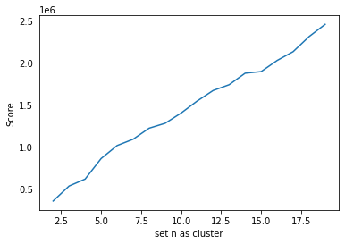

```python
# Load the data (the path may be different for you, adjust if needed)
retail = pd.read_csv("online_retail_full.csv", index_col=False)
#print(retail)
retail_test1 = retail.drop(columns=['Description', 'Country','InvoiceDate','StockCode','Invoice','Customer ID'])
#print(retail_test1)
df13 = retail_test1.to_numpy()
#print(df13)
#print(type(df13))
list13 =[]
list13_helper=[]
for i13 in range(2,20):
    kmeans_model13 = KMeans(n_clusters=i13,  random_state=1).fit(df13)
    labels13 = kmeans_model13.labels_
    list13.append(metrics.calinski_harabasz_score(df13, labels13))
    list13_helper.append(i13)
df13result = pd.DataFrame({
    'Score':list13,
    'set n as cluster': list13_helper
})
print(df13result)
sns.lineplot(data=df13result, x='set n as cluster', y='Score')
```

#### Discussion of test 1

In the test1, we only used two columns "Price" and "Quantity" as features. Since not all feature has been used, it makes our clustering is not very reliable. From the output graph, it is clear to see more cluster shown better performance in the calinski harabasz index method. Due to the trend of a line graph shows keep increasing from 2 to 20 clusters. It means we have not found a true number of clusters in this test. The two majority problems are we have not used all features and calinski harabasz index may not be performed well for this large size of the dataset.

#### 2.Feature transformation

Since in the last test, we have not found the true number of clusters. This test will try to work with more features to find the true number of clusters. The country is a helpful feature to support clustering. Due to the k-means algorithm in sk-learn does not support type string as input. There is one approach to transformation the country name to country id. Then add country id as a new column to the data frame. Therefore, the country feature will be work for clusrtering.

[output not shown]

[output cut: 11 more lines]

```
3   8.567798e+05                 5
4   1.008629e+06                 6
5   1.081435e+06                 7
6   1.213908e+06                 8
7   1.272221e+06                 9
8   1.378958e+06                10
9   1.516645e+06                11
10  1.632335e+06                12
11  1.685997e+06                13
12  1.790654e+06                14
13  1.890662e+06                15
14  1.969053e+06                16
15  2.045704e+06                17
16  2.123949e+06                18
17  2.202378e+06                19
```

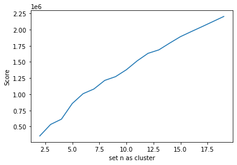

```python
retail = pd.read_csv("online_retail_full.csv", index_col=False)
list_c = pd.read_csv("online_retail_full.csv")['Country']
set1 =set()
for data in list_c:
    set1.add(data)
print(set1)
list_set = list(set1)
print(list_set)
list_cid = []
for data in list_c:
    list_cid.append(list_set.index(data))
retail['Country id'] = list_cid
print(retail)

retail_test2 = retail.drop(columns=['Description', 'Country','InvoiceDate','StockCode','Invoice','Customer ID'])
df13_2 = retail_test2.to_numpy()
list13_2 =[]
list13_2_helper=[]
for i13_2 in range(2,20):
    kmeans_model13_2 = KMeans(n_clusters=i13_2,  random_state=1).fit(df13_2)
    labels13_2 = kmeans_model13_2.labels_
    list13_2.append(metrics.calinski_harabasz_score(df13_2, labels13_2))
    list13_2_helper.append(i13_2)
df13_2result = pd.DataFrame({
    'Score':list13_2,
    'set n as cluster': list13_2_helper
})
print(df13_2result)
sns.lineplot(data=df13_2result, x='set n as cluster', y='Score')
```

#### Disscussion of Q1.3 test2

In this experiment, I was trying to used

"list13_2.append(metrics.silhouette_score(df13_2, labels13_2))"

instead of

"list13_2.append(metrics.calinski_harabasz_score(df13_2, labels13_2))"

to get silhouette score, and use silhouette score to evaluate and find true number of clusters. However,the silhouette function worked very slowly. I have try to reduce the range of value to make it work, and the program still did not work. Therefore, this test is still using calinski harabasz score to estimate the true number of clusters.

The resulting output line graph is similar to test 1, more numbers of clusters performed better in calinski harabasz score. It may cause by the size of data being very large to require more clusters.

#### 3.Further experiment for a large number of clusters

```
20
21
22
23
24
25
26
27
28
29
```

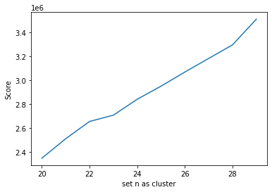

```python
list13_3 =[]
list13_3_helper=[]
for i13_3 in range(20,30):
    kmeans_model13_3 = KMeans(n_clusters=i13_3,  random_state=1).fit(df13_2)
    labels13_3 = kmeans_model13_3.labels_
    list13_3.append(metrics.calinski_harabasz_score(df13_2, labels13_3))
    list13_3_helper.append(i13_3)
    print(i13_3)
df13_3result = pd.DataFrame({
    'Score':list13_3,
    'set n as cluster': list13_3_helper
})
sns.lineplot(data=df13_3result, x='set n as cluster', y='Score')
```

#### Disscussion of Q1.3 test3

From this output, we could find the true number of cluster in this dataset is higher than 29. We will need more time to do some further experiment to find this true number of cluster.

#### Disscussion of Q1.3

# Question 2: Itemset Rule Mining (4 marks)

For this question, we will be using a [real-world dataset](https://archive.ics.uci.edu/ml/datasets/Congressional+Voting+Records) which gives the votes of 435 U.S. congressmen on 16 key issues gathered in the mid-1980s, and also includes their party affiliation as a binary attribute. This is a purely nominal dataset with some missing values (corresponding to abstentions). It is normally treated as a classification problem, the task being to predict party affiliation based on voting patterns. However, association-rule mining can also be applied to this data to seek interesting associations.

We will be using [Weka](https://www.cs.waikato.ac.nz/ml/weka/), both for its utility for itemset rule mining, and to use a different approach for exploring data. You should have some experience using Weka from the first (non-assessed) week.

You may need to take screenshots of Weka and include them in your answer below, or copy & paste the relevant rules. Please ensure that your answer and rules are clearly legible.

## Q2.1 (3 marks)

In Weka, run `Apriori` on this dataset using default settings. Comment on any patterns you see in the rules that are generated. Also discuss their support, confidence, and lift, demonstrating that you understand how they are calculated, their role, and how to interpret these values.

## Q2.1 Answer

When run Apriori on this dataset with default setting, we need to focus on the support, confidence, and lift in the association rules. The association rules are able to find associations and correlation relationships for the large size of data. The support indicates the sum number of transactions, which include items in the antecedent and consequent parts of the rule [4].

The calculation of support of X is (transaction with event X)/(Total number of transaction)

Another key element is called confidence, it is the possibility of event B happening when event A has already happened [5]. The lift is the possibility of event B happening when event A has already happened. Furthermore, it is also consider the support of event B. It is the ratio of Confidence to Expected Confidence[4].

The Confidence(A->B) = Support(A,B)/Support(A)

At the same time, it is able to provide the information about the increase in the probability of consequent given the antecedent.

The lift(A->B) = Support(A,B)/Support(A)* Support(B)

Therefore, the Minimum support: 0.45 (196 instances) indicates the popular thershold has been set as 0.45. Only support larger than this thershold will be consider as important event. Minimum metric : 0.9 means only confidence larger than 0.9 will be seen as possible event. The lift:(value) for each best rule is used to measure the importance of a rule [6].

#### copy & paste the relevant rules

=== Run information ===

Scheme: weka.associations.Apriori -N 10 -T 0 -C 0.9 -D 0.05 -U 1.0 -M 0.1 -S -1.0 -c -1 Relation: vote Instances: 435 Attributes: 17 handicapped-infants water-project-cost-sharing adoption-of-the-budget-resolution physician-fee-freeze el-salvador-aid religious-groups-in-schools anti-satellite-test-ban aid-to-nicaraguan-contras mx-missile immigration synfuels-corporation-cutback education-spending superfund-right-to-sue crime duty-free-exports export-administration-act-south-africa Class === Associator model (full training set) ===

# Apriori

Minimum support: 0.45 (196 instances) Minimum metric : 0.9 Number of cycles performed: 11

Generated sets of large itemsets:

Size of set of large itemsets L(1): 20

Size of set of large itemsets L(2): 17

Size of set of large itemsets L(3): 6

Size of set of large itemsets L(4): 1

Best rules found:

1. adoption-of-the-budget-resolution=y physician-fee-freeze=n 219 ==> Class=democrat 219 conf:(1) lift:(1.63) lev:(0.19) [84] conv:(84.58)
2. adoption-of-the-budget-resolution=y physician-fee-freeze=n aid-to-nicaraguan-contras=y 198 ==> Class=democrat 198 conf:(1) lift:(1.63) lev:(0.18) [76] conv:(76.47)
3. physician-fee-freeze=n aid-to-nicaraguan-contras=y 211 ==> Class=democrat 210 conf:(1) lift:(1.62) lev:(0.19) [80] conv:(40.74)
4. physician-fee-freeze=n education-spending=n 202 ==> Class=democrat 201 conf:(1) lift:(1.62) lev:(0.18) [77] conv:(39.01)
5. physician-fee-freeze=n 247 ==> Class=democrat 245 conf:(0.99) lift:(1.62) lev:(0.21) [93] conv:(31.8)
6. el-salvador-aid=n Class=democrat 200 ==> aid-to-nicaraguan-contras=y 197 conf:(0.98) lift:(1.77) lev:(0.2) [85] conv:(22.18)
7. el-salvador-aid=n 208 ==> aid-to-nicaraguan-contras=y 204 conf:(0.98) lift:(1.76) lev:(0.2) [88] conv:(18.46)
8. adoption-of-the-budget-resolution=y aid-to-nicaraguan-contras=y Class=democrat 203 ==> physician-fee-freeze=n 198 conf:(0.98) lift:(1.72) lev:(0.19) [82] conv:(14.62)
9. el-salvador-aid=n aid-to-nicaraguan-contras=y 204 ==> Class=democrat 197 conf:(0.97) lift:(1.57) lev:(0.17) [71] conv:(9.85)
   1. aid-to-nicaraguan-contras=y Class=democrat 218 ==> physician-fee-freeze=n 210 conf:(0.96) lift:(1.7) lev:(0.2) [86] conv:(10.47)

#### Screenshots of Weka

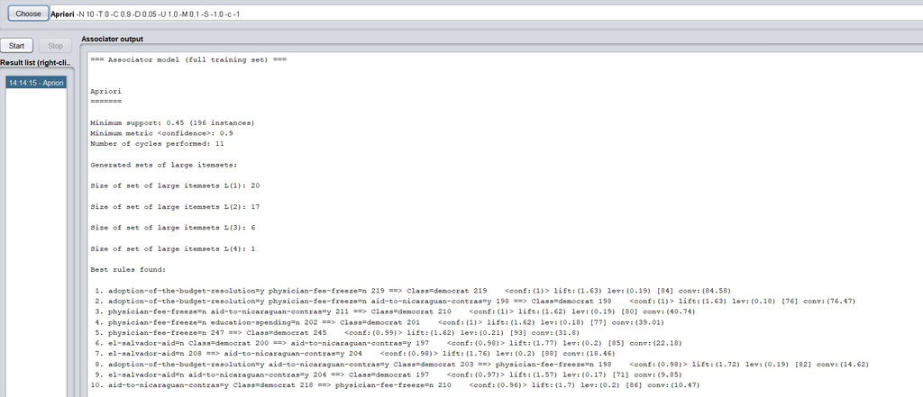

```python
from IPython.display import Image
Image(filename='task2_1.jpg')
```

## Q2.2 (1 mark)

It is interesting to see that none of the rules in the default output involve `class = republican`. Why do you think that is?

## Q2.2 Answer

There are several potential issues to cause that. Firstly, for the number of instances, 267 of 435 are democrats. At the same time, only 168 of 435 are republican. It makes both support and confidence will have more possibility of democrats. Secondly, the setting of minimum metric is 0.9 which is quite high value. At the same time, democrats contained 61% of the instance. Therefore, this is a reasonable result for this default setting and data set.

# Reference:

[1] P.N.Tan, M.Steinbach, V,Kumar. Cluster Analysis: Basic Concepts and Algorithms, 2005, [Online],Available at: https://www-users.cse.umn.edu/~kumar001/dmbook/ch8.pdf [Accessed 28/10/2021]

[2] Error Bars,[Online],Available at: https://datavizcatalogue.com/methods/error_bars.html [Accessed 28/10/2021]

[3] Clustering performance evaluation,[Online], Available at: https://scikit-learn.org/stable/modules/clustering.html#clustering-performance-evaluation [Accessed 28/10/2021]

[4] ASSOCIATION RULES, [Online],Available at: https://www.solver.com/xlminer/help/association-rules [Accessed 28/10/2021]

[5] KDnuggests, Association Rules and the Apriori Algorithm: A Tutorial,[Online], Available at: https://www.kdnuggets.com/2016/04/association-rules-apriori-algorithm-tutorial.html [Accessed 28/10/2021]

[6] Lift in an association rule, [Online], Available at: https://www.ibm.com/docs/en/db2/9.7?topic=associations-lift-in-association-rule [Accessed 28/10/2021]